# Linear Model for Forecasting the Total Number of Newly Established Firms

Tufan Berk Tug - IE360 - Fall 2020

# 1.Introduction

In this study, the aim is to create a linear model to yield sensible forecasts on the number of newly established firms, using related independent data from EVDS. Since the number of newly established firms highly depends on the general economic situation, most of the considered data is indicators of the general economic situation of Turkey. Let’s check which variables are considered for what reason: Total Industrial Production: Since most of the companies use the goods produced by industries in Turkey as raw material, volume of this production may be highly correlated with the new enterprises. High production volumes would create surplus, which can be a good incentive to start new businesses. Exchange Rates and Interest Rates: Exchange rates are one of the most valuable data in the domain of economic research. Any fluctuation in the exchange rates affects all businesses as we have an open market economy conditions in Turkey. On the other hand, interest rates are also very important since it determines the attractiveness of using loans to start businesses. It should be noted that commercial loans average interest rates are used since it is the one used for businesses. Producer Price Index: Just like the volume of industrial production, prices of the goods used by producers are very important factors. In times that it is relatively cheaper to run a business due to low PPI, people will be more encouraged to start new enterprises. Financial Situation of Household and General Economic Situation: Because it is very risky to start a business from scratch, it is likely that the financial situation of people is correlated with our target variable. Also the perceived general economic situation of the country is also important since customers of businesses are residents of the country most of the time. It should be noted that these data are derived from surveys. The Probability of Saving: Being another survey derived data, expectation of possible future savings may also be correlated since these savings are useful for funding new businesses. Unemployment: High unemployment rate means that there are more potential entrepreneurs and employees for new firms. Since it is hard for anyone to take the risk of abandoning already established living standards by resigning, already unemployed people are more likely to start new businesses.

# 2.Analysis

## a.Data Manipulation

To start with, data mentioned in introduction must be imported from the excel file with read_excel function and brought to an understandable and more useful shape with some manipulations. First entries with column names can be seen after manipulation as an example:

```r
data1 <- as.data.table(read_excel("hw3.xlsx", range = "A1:K108"))
names(data1) <- c("Date", "IndProd", "ExcRate", "IntRate", "DPPI", "NDPPI", "FSH", "GES", "PS", "TNEF", "UnEmp")
data1$Date <- as.yearmon(data1$Date)
head(data1)
```

```
##        Date  IndProd  ExcRate IntRate     DPPI  NDPPI      FSH       GES
## 1: Oca 2012 74.97504 1.838936 15.2975 203.0991 120.21 82.32061  98.08557
## 2: Şub 2012 73.39412 1.751090 14.8650 202.9109 117.76 83.89667  99.95948
## 3: Mar 2012 83.76683 1.779295 14.1840 203.6438 119.58 82.59077 100.55675
## 4: Nis 2012 80.29805 1.779840 14.1825 203.8122 119.21 79.78069  94.29014
## 5: May 2012 86.81221 1.796955 14.0475 204.8918 118.89 83.24362  99.40186
## 6: Haz 2012 86.14740 1.816071 14.3080 201.8312 118.01 82.90206  96.42632
##          PS TNEF UnEmp
## 1: 29.94013 5328   9.3
## 2: 26.57602 3894   9.6
## 3: 27.64935 3663   9.1
## 4: 26.24446 3272   8.2
## 5: 25.94124 3250   7.6
## 6: 23.60030 3083   7.3
```

## b.Data Visualisation and Analysis

### Target Variable Analysis and Trend Component

Firstly, it would be a good idea to analyze our main data, the number of newly establish firms, to see any pattern which may be useful in the linear model. So we start by visualizing the data in a plot:

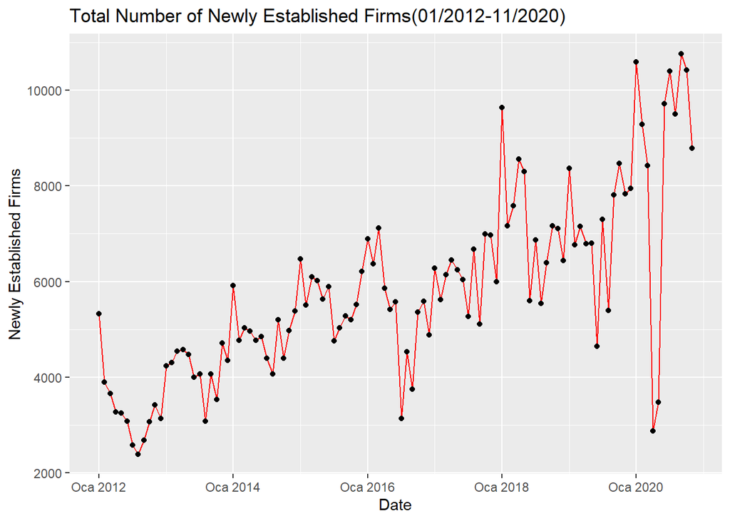

```
##
## Call:
## lm(formula = TNEF ~ Trend + as.factor(Month), data = data1)
##
## Residuals:
##     Min      1Q  Median      3Q     Max
## -4928.6  -445.3    82.2   436.3  2771.8
##
## Coefficients:
##                     Estimate Std. Error t value Pr(>|t|)
## (Intercept)         4708.983    423.926  11.108  < 2e-16 ***
## Trend                 48.368      3.631  13.322  < 2e-16 ***
## as.factor(Month)2  -1161.701    544.186  -2.135 0.035383 *
## as.factor(Month)3   -982.624    544.223  -1.806 0.074189 .
## as.factor(Month)4  -1739.103    544.283  -3.195 0.001903 **
## as.factor(Month)5  -1897.582    544.368  -3.486 0.000747 ***
## as.factor(Month)6  -1832.061    544.477  -3.365 0.001110 **
## as.factor(Month)7  -1950.317    544.610  -3.581 0.000544 ***
## as.factor(Month)8  -2284.463    544.767  -4.193 6.21e-05 ***
## as.factor(Month)9  -1795.386    544.949  -3.295 0.001391 **
## as.factor(Month)10 -1448.309    545.155  -2.657 0.009272 **
## as.factor(Month)11 -1461.344    545.384  -2.679 0.008706 **
## as.factor(Month)12 -1774.963    561.216  -3.163 0.002105 **
## ---
## Signif. codes:  0 '***' 0.001 '**' 0.01 '*' 0.05 '.' 0.1 ' ' 1
##
## Residual standard error: 1154 on 94 degrees of freedom
## Multiple R-squared:  0.6779, Adjusted R-squared:  0.6368
## F-statistic: 16.49 on 12 and 94 DF,  p-value: < 2.2e-16
```

By checking p-values of F and T statistics, we can easily say that trend and months are significant factors. However, there is still a large unexplained portion of variance as R-squared value is 0.6368. We will try to explain them using the independent variables. But first, let’s check the residuals of the model to see if assumptions of linear models hold or not:

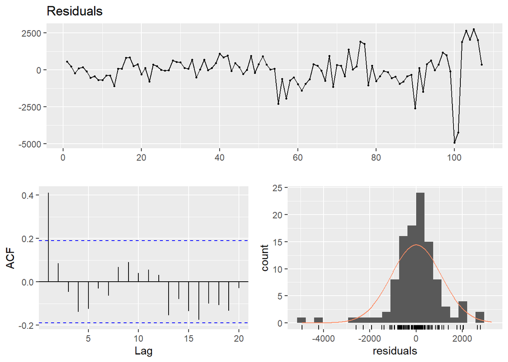

```
##
##  Breusch-Godfrey test for serial correlation of order up to 16
##
## data:  Residuals
## LM test = 39.584, df = 16, p-value = 0.0008951
```

Zero mean for residuals assumption seems to be satisfied. Unchanging variance assumption is not explicitly violated except the pandemic uncertainty period. Residuals are highly autocorrelated at lag 1 although we used trend component. In order to get rid of autocorrelation, we can use lagged residual values as a parameter in linear model:

```
##
## Call:
## lm(formula = TNEF ~ Trend + as.factor(Month) + Residual_1, data = data1)
##
## Residuals:
##     Min      1Q  Median      3Q     Max
## -4910.7  -406.6    25.8   506.4  3621.9
##
## Coefficients:
##                      Estimate Std. Error t value Pr(>|t|)
## (Intercept)         4.616e+03  4.191e+02  11.014  < 2e-16 ***
## Trend               4.876e+01  3.384e+00  14.408  < 2e-16 ***
## as.factor(Month)2  -1.088e+03  5.164e+02  -2.108 0.037766 *
## as.factor(Month)3  -9.097e+02  5.163e+02  -1.762 0.081371 .
## as.factor(Month)4  -1.667e+03  5.162e+02  -3.229 0.001725 **
## as.factor(Month)5  -1.825e+03  5.161e+02  -3.537 0.000637 ***
## as.factor(Month)6  -1.760e+03  5.161e+02  -3.411 0.000964 ***
## as.factor(Month)7  -1.879e+03  5.161e+02  -3.641 0.000449 ***
## as.factor(Month)8  -2.214e+03  5.161e+02  -4.289 4.42e-05 ***
## as.factor(Month)9  -1.725e+03  5.161e+02  -3.342 0.001204 **
## as.factor(Month)10 -1.378e+03  5.162e+02  -2.670 0.008971 **
## as.factor(Month)11 -1.392e+03  5.163e+02  -2.695 0.008357 **
## as.factor(Month)12 -1.685e+03  5.311e+02  -3.172 0.002055 **
## Residual_1          4.107e-01  9.495e-02   4.325 3.86e-05 ***
## ---
## Signif. codes:  0 '***' 0.001 '**' 0.01 '*' 0.05 '.' 0.1 ' ' 1
##
## Residual standard error: 1062 on 92 degrees of freedom
##   (1 observation deleted due to missingness)
## Multiple R-squared:  0.733,  Adjusted R-squared:  0.6953
## F-statistic: 19.43 on 13 and 92 DF,  p-value: < 2.2e-16
```

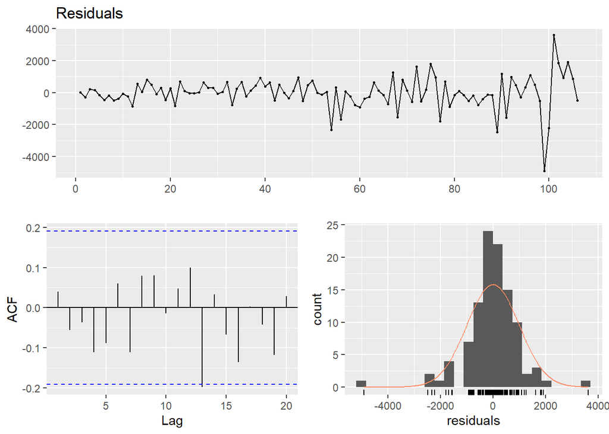

```
##
##  Breusch-Godfrey test for serial correlation of order up to 17
##
## data:  Residuals
## LM test = 26.473, df = 17, p-value = 0.06626
```

Now, we have a better R-squared value and no apparent autocorrelation. Let’s start considering the independent variables.

### Independent Variable Analysis and Extended Linear Models

#### Interest Rate

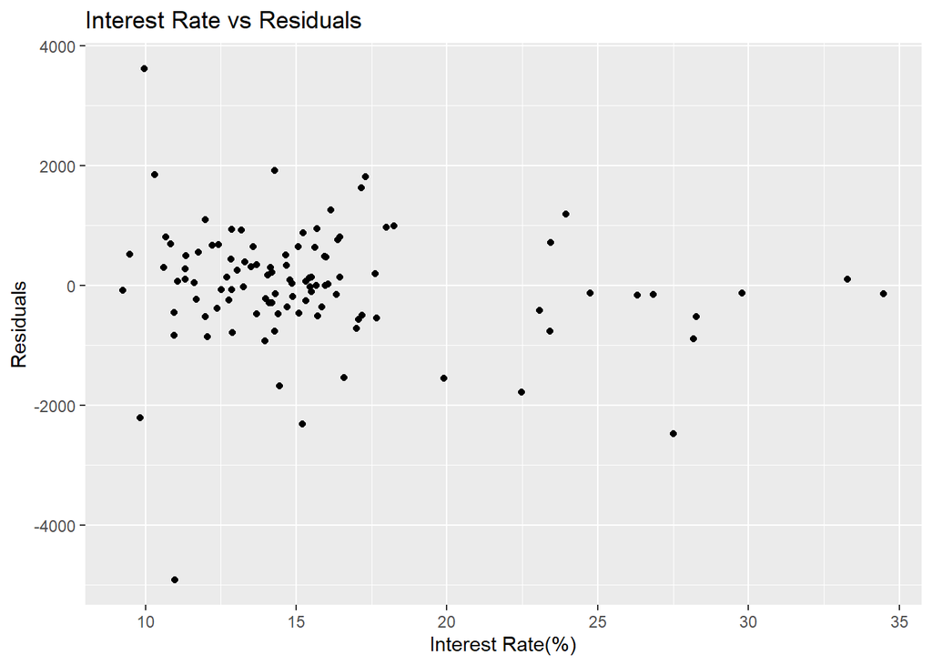

Unfortunately, interest rate doesn’t seem to be able to help us since the points on the plot are scattered and interest rate and our residuals are seemingly not correlated.

#### Exchange Rate

Now, we will apply the same comparison methods to see if exchange rate (US Dollar/Turkish Lira) helps us:

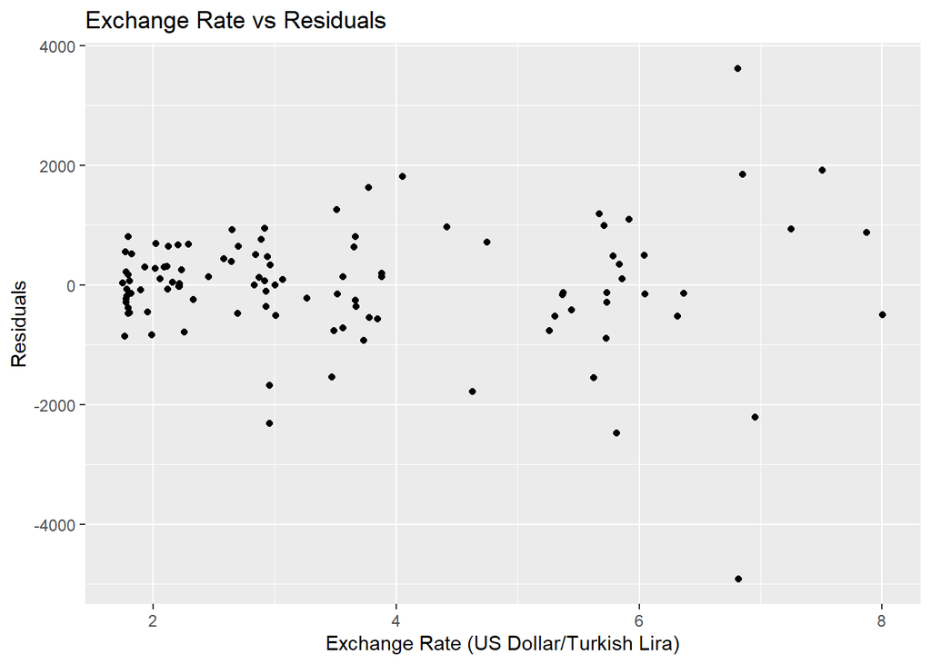

Exchange rates also do not show any relation with residuals.

#### Industrial Production

As mentioned before, industrial production volumes may help us explain the target variable. We will plot it against residuals as we did before:

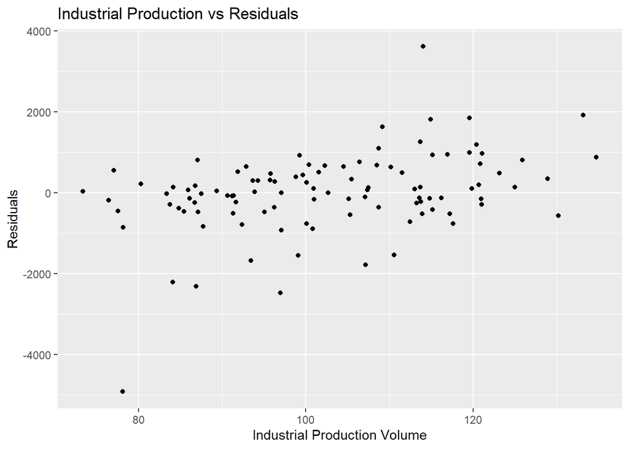

Luckily, residuals and industrial production volume seem to have a positive relationship and incorporating industrial production data into our linear model will help us yield better estimates:

```
##
## Call:
## lm(formula = TNEF ~ Trend + as.factor(Month) + Residual_1 + IndProd,
##     data = data1)
##
## Residuals:
##     Min      1Q  Median      3Q     Max
## -1484.1  -472.1    68.1   390.4  3290.8
##
## Coefficients:
##                      Estimate Std. Error t value Pr(>|t|)
## (Intercept)        -2.800e+03  8.188e+02  -3.420 0.000943 ***
## Trend               1.514e+01  4.255e+00   3.558 0.000598 ***
## as.factor(Month)2  -9.562e+02  3.648e+02  -2.621 0.010296 *
## as.factor(Month)3  -1.889e+03  3.783e+02  -4.995 2.87e-06 ***
## as.factor(Month)4  -2.031e+03  3.664e+02  -5.544 2.93e-07 ***
## as.factor(Month)5  -2.588e+03  3.728e+02  -6.941 5.81e-10 ***
## as.factor(Month)6  -2.375e+03  3.699e+02  -6.421 6.24e-09 ***
## as.factor(Month)7  -2.642e+03  3.728e+02  -7.088 2.96e-10 ***
## as.factor(Month)8  -2.447e+03  3.652e+02  -6.700 1.76e-09 ***
## as.factor(Month)9  -2.738e+03  3.791e+02  -7.223 1.58e-10 ***
## as.factor(Month)10 -2.747e+03  3.908e+02  -7.029 3.88e-10 ***
## as.factor(Month)11 -2.846e+03  4.068e+02  -6.997 4.49e-10 ***
## as.factor(Month)12 -3.581e+03  4.229e+02  -8.468 4.39e-13 ***
## Residual_1          2.531e-01  7.051e-02   3.589 0.000539 ***
## IndProd             9.757e+01  1.006e+01   9.697 1.22e-15 ***
## ---
## Signif. codes:  0 '***' 0.001 '**' 0.01 '*' 0.05 '.' 0.1 ' ' 1
##
## Residual standard error: 749.9 on 90 degrees of freedom
##   (2 observations deleted due to missingness)
## Multiple R-squared:  0.8667, Adjusted R-squared:  0.846
## F-statistic: 41.81 on 14 and 90 DF,  p-value: < 2.2e-16
```

As we guessed, industrial production is a significant factor in the linear model and residual standard error dropped from 1062 to 749.9. New adjusted R-squared value is 0.846 which is considerably higher than the first model we established. Let’s check the residual analysis of our new model to see if we could eliminate the assumption violations:

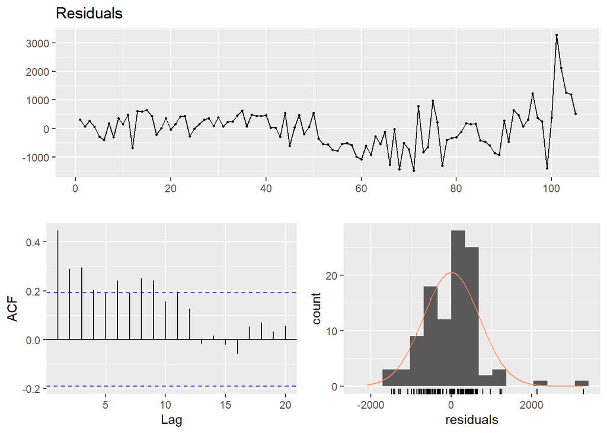

```
##
##  Breusch-Godfrey test for serial correlation of order up to 18
##
## data:  Residuals
## LM test = 51.914, df = 18, p-value = 3.857e-05
```

Autocorrelation problem came up again, so it is better to update lagged residual values.

```
##
## Call:
## lm(formula = TNEF ~ Trend + as.factor(Month) + Residual_1 + IndProd,
##     data = data1)
##
## Residuals:
##      Min       1Q   Median       3Q      Max
## -1533.32  -296.87    29.26   312.07  2570.22
##
## Coefficients:
##                      Estimate Std. Error t value Pr(>|t|)
## (Intercept)        -3.341e+03  6.808e+02  -4.907 4.09e-06 ***
## Trend               1.276e+01  3.540e+00   3.606  0.00051 ***
## as.factor(Month)2  -9.463e+02  3.110e+02  -3.042  0.00308 **
## as.factor(Month)3  -1.960e+03  3.218e+02  -6.091 2.72e-08 ***
## as.factor(Month)4  -2.058e+03  3.123e+02  -6.589 2.92e-09 ***
## as.factor(Month)5  -2.643e+03  3.174e+02  -8.326 8.63e-13 ***
## as.factor(Month)6  -2.419e+03  3.151e+02  -7.679 1.86e-11 ***
## as.factor(Month)7  -2.697e+03  3.174e+02  -8.499 3.80e-13 ***
## as.factor(Month)8  -2.464e+03  3.113e+02  -7.914 6.14e-12 ***
## as.factor(Month)9  -2.811e+03  3.225e+02  -8.719 1.33e-13 ***
## as.factor(Month)10 -2.846e+03  3.319e+02  -8.575 2.63e-13 ***
## as.factor(Month)11 -2.928e+03  3.440e+02  -8.511 3.58e-13 ***
## as.factor(Month)12 -3.730e+03  3.580e+02 -10.418  < 2e-16 ***
## Residual_1          6.094e-01  8.488e-02   7.179 1.93e-10 ***
## IndProd             1.046e+02  8.321e+00  12.575  < 2e-16 ***
## ---
## Signif. codes:  0 '***' 0.001 '**' 0.01 '*' 0.05 '.' 0.1 ' ' 1
##
## Residual standard error: 639.3 on 90 degrees of freedom
##   (2 observations deleted due to missingness)
## Multiple R-squared:  0.9031, Adjusted R-squared:  0.8881
## F-statistic: 59.93 on 14 and 90 DF,  p-value: < 2.2e-16
```

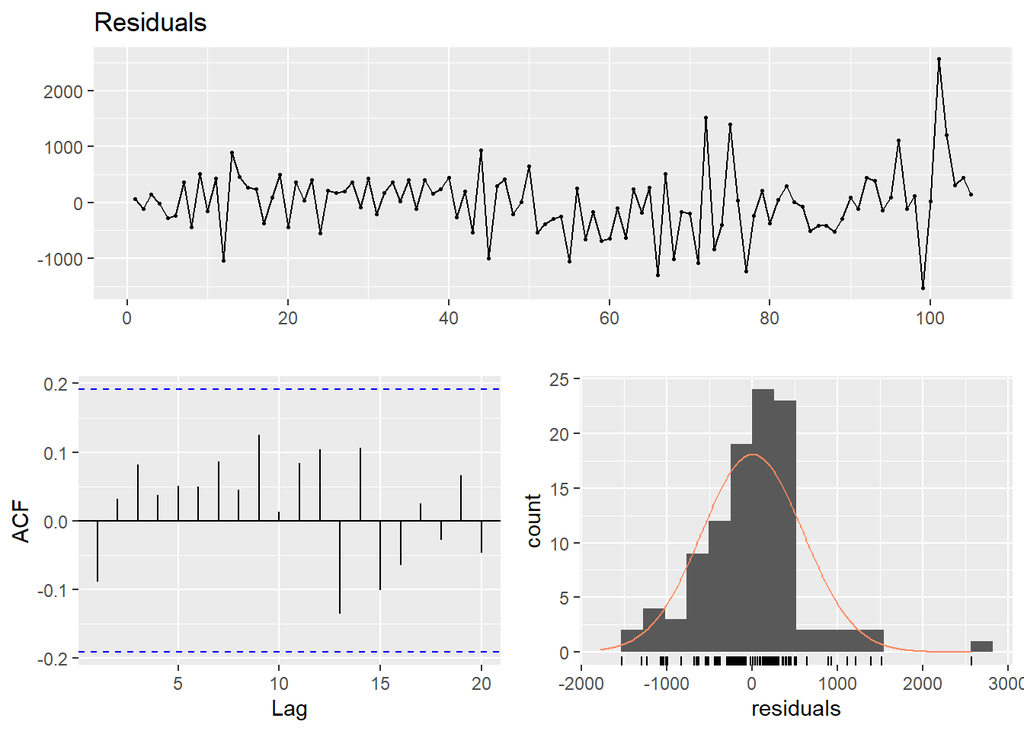

```
##
##  Breusch-Godfrey test for serial correlation of order up to 18
##
## data:  Residuals
## LM test = 21.413, df = 18, p-value = 0.2591
```

After the update, our model is better in every aspect. Autocorrelation test gives considerably higher p-value compared to the one without industrial production. The only problem is the lack of normality of the residuals. We can continue to check whether other independent values can help us.

#### Domestic Producer Price Index

Conducting the same steps as before, we yield the following plot:

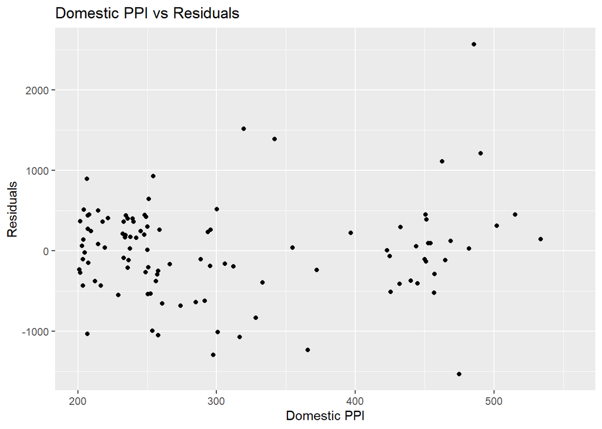

DPPI also show no correlation with model’s residuals. Since Non-domestic PPI is a combination of the effects of Domestic PPI and exchange rate, and both of them were uncorrelated, I will not waste time on checking it.

#### Financial Situtation of Household

Let’s check if the perceived financial situation of people’s selves helps us in explaining the residuals:

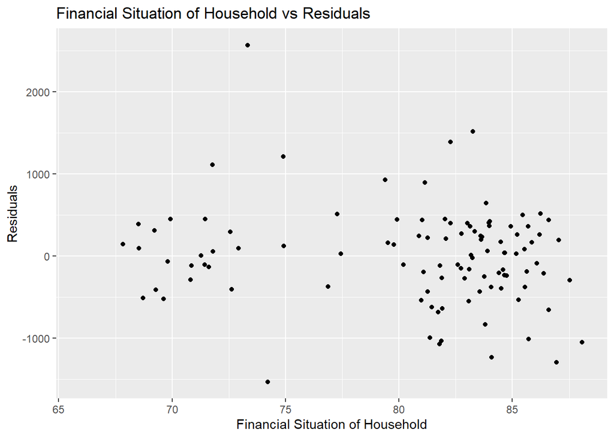

Apparently, there is no significant relationship between residuals and FSH.

#### General Economic Situtation

Instead of the perceived self economic situation, now check the perceived general economic situation in Turkey:

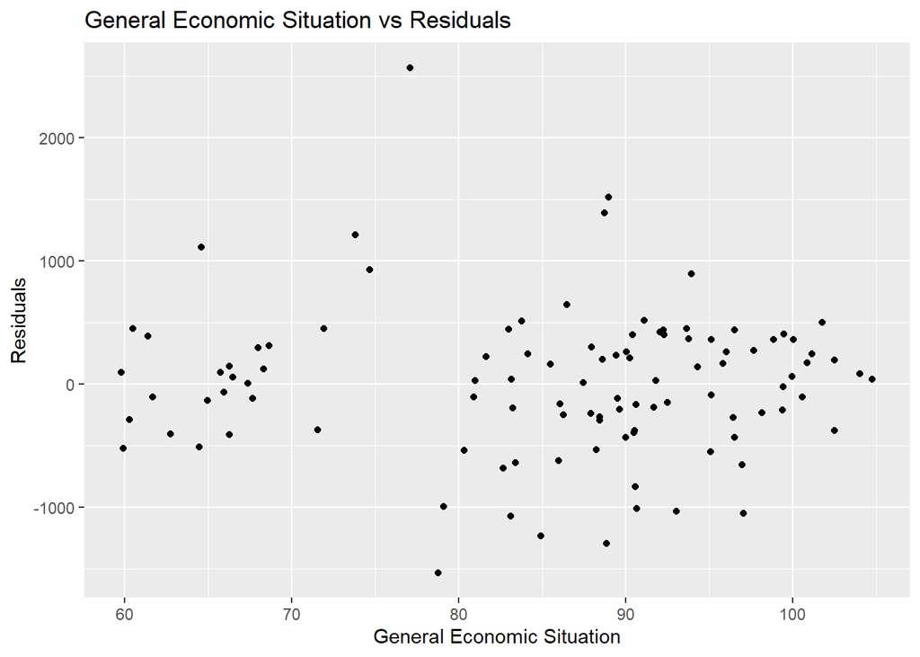

Just like the FSH, General Economic Situation survey results do not help us explaining the residuals.

#### Probability of Saving

Just before the unemployment data, let’s check the last survey data that we use:

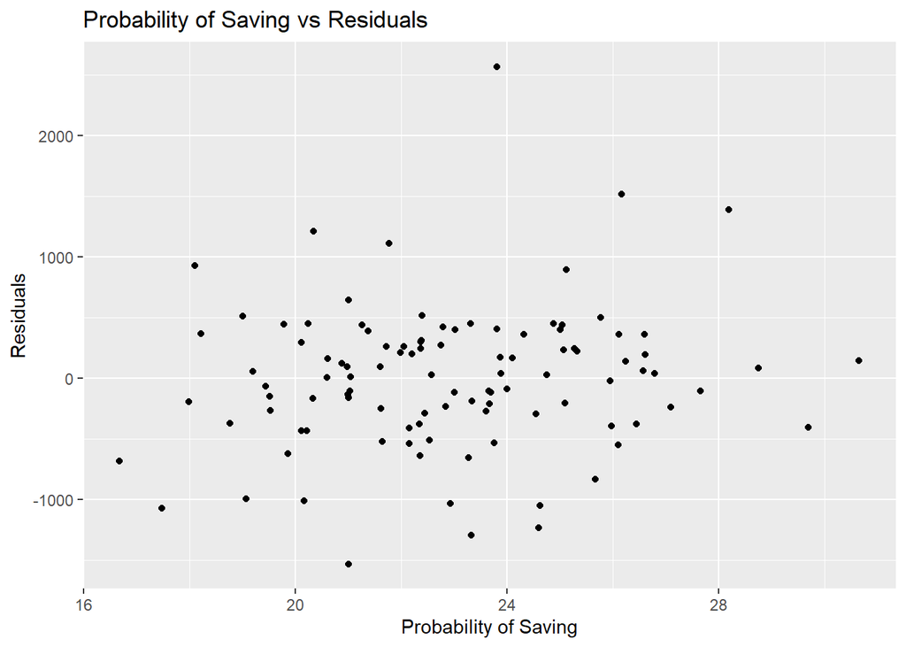

Probability of saving data is also show a scattered fashion versus Residuals data. So, it also doesn’t help our model.

#### Unemployment Rate

Last but not least, it is the for unemployment rate. In most of the research studies on economy domain, unemployment rate plays an important role. In order to see whether same is valid for our case or not, we will plot it against residuals:

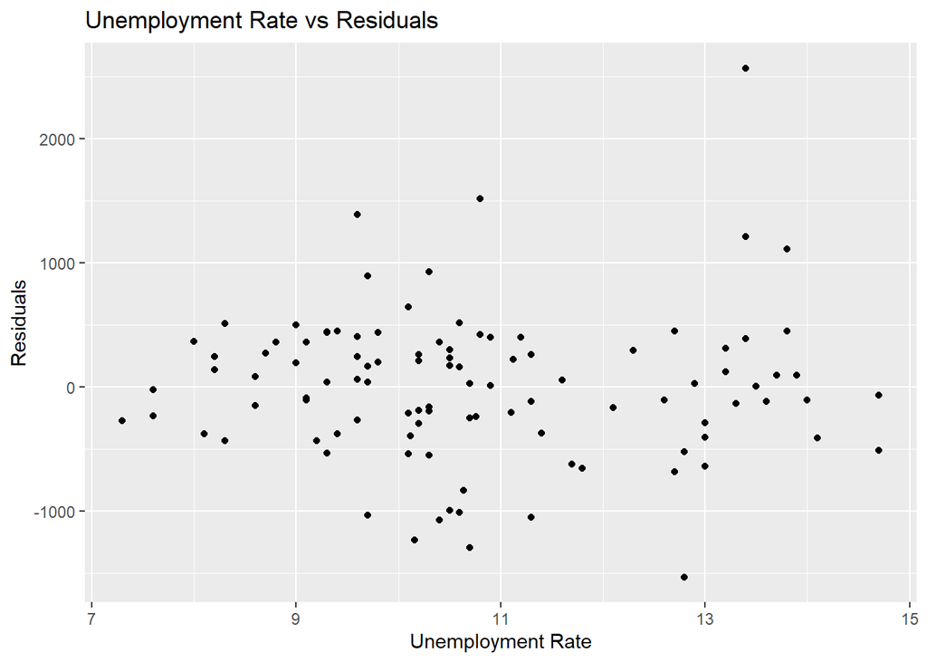

Unemployment rate also does not seem to have any correlation with residuals.

# 3.Conclusion

Although we didn’t incorporate the variables to our linear model except industrial production, they may still be related to target variable. Trend and yearly seasonality components might be the reason why they seem useless to our model since they include the effect of economic parameters with similar patterns. To sum up, we were able to explain the behavior of newly established firms data with the dummy variables created for trend and yearly patterns. The only independent data we used in our model was industrial production volume data. The final version of our model is as follows:

```
##
## Call:
## lm(formula = TNEF ~ Trend + as.factor(Month) + Residual_1 + IndProd,
##     data = data1)
##
## Residuals:
##      Min       1Q   Median       3Q      Max
## -1533.32  -296.87    29.26   312.07  2570.22
##
## Coefficients:
##                      Estimate Std. Error t value Pr(>|t|)
## (Intercept)        -3.341e+03  6.808e+02  -4.907 4.09e-06 ***
## Trend               1.276e+01  3.540e+00   3.606  0.00051 ***
## as.factor(Month)2  -9.463e+02  3.110e+02  -3.042  0.00308 **
## as.factor(Month)3  -1.960e+03  3.218e+02  -6.091 2.72e-08 ***
## as.factor(Month)4  -2.058e+03  3.123e+02  -6.589 2.92e-09 ***
## as.factor(Month)5  -2.643e+03  3.174e+02  -8.326 8.63e-13 ***
## as.factor(Month)6  -2.419e+03  3.151e+02  -7.679 1.86e-11 ***
## as.factor(Month)7  -2.697e+03  3.174e+02  -8.499 3.80e-13 ***
## as.factor(Month)8  -2.464e+03  3.113e+02  -7.914 6.14e-12 ***
## as.factor(Month)9  -2.811e+03  3.225e+02  -8.719 1.33e-13 ***
## as.factor(Month)10 -2.846e+03  3.319e+02  -8.575 2.63e-13 ***
## as.factor(Month)11 -2.928e+03  3.440e+02  -8.511 3.58e-13 ***
## as.factor(Month)12 -3.730e+03  3.580e+02 -10.418  < 2e-16 ***
## Residual_1          6.094e-01  8.488e-02   7.179 1.93e-10 ***
## IndProd             1.046e+02  8.321e+00  12.575  < 2e-16 ***
## ---
## Signif. codes:  0 '***' 0.001 '**' 0.01 '*' 0.05 '.' 0.1 ' ' 1
##
## Residual standard error: 639.3 on 90 degrees of freedom
##   (2 observations deleted due to missingness)
## Multiple R-squared:  0.9031, Adjusted R-squared:  0.8881
## F-statistic: 59.93 on 14 and 90 DF,  p-value: < 2.2e-16
```

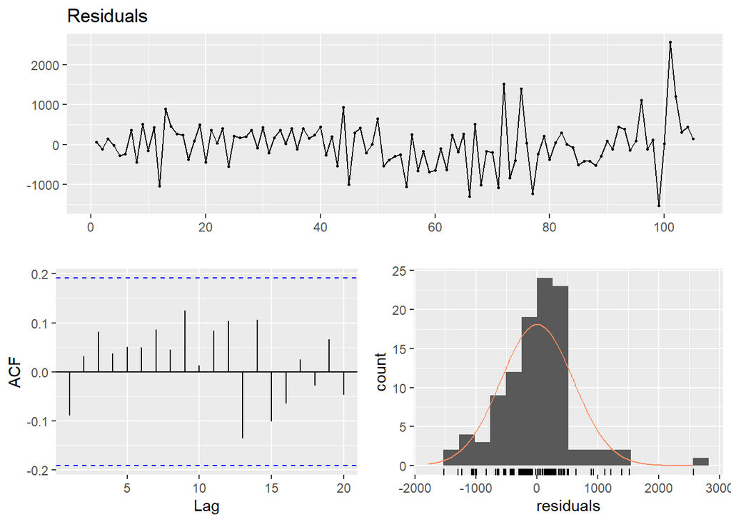

```
##
##  Breusch-Godfrey test for serial correlation of order up to 18
##
## data:  Residuals
## LM test = 21.413, df = 18, p-value = 0.2591
```

We can’t make a prediction for next level of target variables due to the missing data. It could be overcame by using lagged values of missing data.